# Size symbolism in production and perception

A Bayesian analysis of duration, f0, and animacy

anonymized for peer review

2026-09-19

```r
########## folders ##########
setwd(dirname(rstudioapi::getActiveDocumentContext()$path))
parentfolder  <- dirname(getwd())
models        <- paste0(parentfolder, '/models/')
plots         <- paste0(parentfolder, '/plots/')
scripts       <- paste0(parentfolder, '/scripts/')
data_dir      <- paste0(parentfolder, '/data/')   # adjust if data lives elsewhere

########## folder creation (security: only if missing) ##########
if (!dir.exists(plots))   dir.create(plots,   recursive = TRUE)
if (!dir.exists(models))  dir.create(models,  recursive = TRUE)
if (!dir.exists(scripts)) dir.create(scripts, recursive = TRUE)
if (!dir.exists(data_dir)) dir.create(data_dir, recursive = TRUE)

knitr::opts_chunk$set(
  fig.path = plots
)

#################### packages ####################
# Core tidyverse for wrangling + plotting; janitor/skimr for quick structure checks; patchwork for combining plots
library(tidyverse)
library(janitor)
library(skimr)
library(knitr)
library(cowplot)
library(patchwork)
library(ggdist)
# Bayesian
library(brms);
library(loo);packageVersion("loo")
```

```
## [1] '2.9.0'
```

```r
library(HDInterval);packageVersion("HDInterval")
```

```
## [1] '0.2.4'
```

```r
library(cmdstanr);
library(emmeans);packageVersion("emmeans")
```

```
## [1] '2.0.2'
```

```r
library(posterior);
library(bayesplot);
library(BayesFactor);
library(tidybayes);packageVersion("tidybayes")
```

```
## [1] '3.0.7'
```

```r
library(bayestestR);
library(cmdstanr)

options(brms.backend = "cmdstanr") # Speed gain: ~30-50% faster than rstan
options(brms.file_refit = "on_change")  # only refit if model changes

# use all available cores for parallel computing
options(mc.cores = parallel::detectCores())
theme_set(theme_tidybayes() + panel_border());

# Keep plots/readability consistent
theme_set(theme_minimal(base_size = 14))
colorBlindBlack8  <- c("#000000", "#E69F00", "#56B4E9", "#009E73",
                       "#F0E442", "#0072B2", "#D55E00", "#CC79A7")

# Figure and Table caption adapted from https://stackoverflow.com/questions/37116632/rmarkdown-html-number-figures:
outputFormat = opts_knit$get("rmarkdown.pandoc.to"); # determine the output format of the document
if( is.null(outputFormat) ) outputFormat = ""; # probably not run within knittr
capTabNo = 1; capFigNo = 1; # figure and table caption numbering, for HTML do it manually
#Function to add the Table Number
capTab = function(x)
{
  if(outputFormat == 'html'){
    x = paste0("**Table ",capTabNo,".** ",x,"")
    capTabNo <<- capTabNo + 1
  }; x
}

#Function to add the Figure Number
capFig = function(x, show_R_version=FALSE, show_package_versions=NULL, is_map=FALSE)
{
  if(outputFormat == 'html')
  {
    x <- paste0("**Figure ",capFigNo,".** ",x,"");
    if( show_R_version || (!is.null(show_package_versions) && length(show_package_versions) > 0) )
    {
      x <- paste0(x, " Figure generated using ");
      if( show_R_version ) x <- paste0(x, stringr::str_replace(R.version.string, stringr::fixed("R "), "[`R`](https://www.r-project.org/) "));
      if( !is.null(show_package_versions) && length(show_package_versions) > 0 )
      {
        x <- paste0(x, ifelse( show_R_version, " and ", " "));
        x <- paste0(x, ifelse( length(show_package_versions) > 1, "packages ", "package "));
        x <- paste0(x, paste0(vapply(show_package_versions, function(x) paste0("`",x,"`", " (version ", packageVersion(x),")"), character(1)), collapse=", "), ".");
      }
      if( is_map ) x <- paste0(x, " Maps are using public domain data from the [Natural Earth project](https://www.naturalearthdata.com/) as provided by the `R` package `maps`.");
    }
    capFigNo <<- capFigNo + 1;
  };
  x;
}

########## reproducibility ##########
set.seed(2137)
```

# Overview

**Research question.** Do speakers encode size iconically, and do listeners use those same acoustic cues? Iconicity – a resemblance between linguistic form and meaning (Perniss and Vigliocco 2014) – has moved from a peripheral curiosity to a recognized organizing principle in language (Ćwiek 2022; Ćwiek, Kreiman, and Fuchs 2025; Dingemanse et al. 2015), and size is one of the most robust domains in which it surfaces: from the classic *mil/mal* contrast (Sapir 1929) through the lexicon of English size adjectives (Winter and Perlman 2021) and cross-linguistic patterns (Blasi et al. 2016) to recent work on the acoustic and articulatory bases of size–sound correspondences (Winter 2025).

**Expectations.** We expect both size and animacy to leave a trace on the two most-studied acoustic carriers of iconicity – vowel duration and f0 – and we expect this to hold bidirectionally: in production *and* perception. For size, the predicted direction is longer vowels and lower f0 for big referents, and listeners using those same cues to call “big”. The f0 prediction follows the frequency code (Ohala 1984, 1983), in which lower f0 indexes larger body size across vertebrates; the duration prediction follows recent treatments of iconicity as embedded in continuous acoustic and articulatory parameters rather than discrete phonemic features (Winter 2025; Fuchs and Ćwiek 2022; Perlman et al. 2018). The same auditory analogies are expected to guide listener categorization (Winter and Perlman 2021; Perniss and Vigliocco 2014; Schmidt and Jabeen 2024). For animacy we do not commit to a direction or a channel: animacy may enter as a modulator of the size effect (an interaction) or as an independent shift in the acoustic baseline (a main effect), or both, or neither. We test each of these openly. The literature on animacy and iconic production is mixed, so a single posterior that speaks to both modulation and main-effect possibilities is the safer reporting frame.

**Exploratory.** Other features – F1, F2, fricative duration, fricative SPL, fricative spectral peak, fricative centre of gravity, and the voice-quality measures CPP (Fraile and Godino-Llorente 2014; Hillenbrand, Cleveland, and Erickson 1994) and H1–H2 (Chai and Garellek 2022) – are examined without a priori predictions. The pluripotential view of iconic features (cf. Akita et al. 2024; Winter 2021) motivates inspecting the broader signal rather than committing to a single channel; however, it also warrants the view that few features (f0 and duration) can correspond to many meanings.

**What we find, in one paragraph.** Speakers reliably lengthen vowels and lower f0 for big referents (the production prediction, supported on both channels). Listeners use f0 to judge size – lower f0 raises the odds of a “big” judgment – but do not use vowel duration for the same purpose (the perception prediction is supported for f0, not for duration). The size effect does not differ between animate and inanimate referents. Animate referents in this stimulus set were produced with shorter vowels and higher f0 regardless of their size, but this baseline shift does not survive the inclusion of a separately-collected per-item cuteness covariate (§7.8); we therefore report it descriptively without claiming animacy qua feature as the carrier. Exploratory analyses recover a few additional channels worth flagging – F1 lowers for big, CPP rises slightly for big, fricative SPL is louder for big, and listeners use fricative duration and fricative SPL as cues to size – without claiming these as robust without replication.

This analysis uses the Bayesian framework with the `cmdstanr` backend. All German labels and column names from the original data files are translated to English in the cleaning step so the script and its outputs are readable internationally.

# Decisions log

- **Primary models** include the `size × animacy` interaction so a single posterior speaks to the size effect, the animacy main effect, and the modulation of size by animacy.
- **Random effects (production)**: `(1 + size_c | speaker) + (1 | item)`. 39 speakers, 36 items, ~1400 vowel rows / ~2470 fricative rows – comfortable.
- **Random effects (perception)**: `(1 | listener) + (1 | speaker) + (1 | item)`. 39 × 39 × 36, 936 observations – varying slopes added per-model only if needed.
- **Coding**: sum contrasts `-0.5 / +0.5` for `size_c` and `animacy_c` so main effects remain interpretable in the presence of the interaction. Continuous predictors entering perception models are within-speaker z-scored – the listener-side coefficient then reads as “1 SD shift in *this speaker’s* signal”.
- **Priors**: weakly informative – `normal(0, 1)` on standardized fixed effects, `student_t(3, 0, 2.5)` on intercepts and SDs.
- **Outcome families**:
  - durations (vowel, fricative) → `lognormal()` (strictly positive, right-skewed)
  - f0 → `lognormal()` (positive, right-skewed; with sum-coded `size_c` the coefficient back-transforms cleanly to the ratio of f0 for big vs small)
  - formants (F1, F2) → `lognormal()` (positive, right-skewed)
  - CPP, H1–H2, fricative SPL, fricative peak frequency, fricative CoG → `gaussian()` (centred on their native scale; logging Hz outcomes overshoots the actual right-skew)
  - binary perception (`big_judgment`, `animate_judgment`) → `bernoulli(logit)`
  - 6-way `picked_category` → `categorical()` (kept available in §7.6 but not part of the reported analysis – see §7.6 for the reasoning)
- **Outliers**: not trimmed by default – the lognormal family absorbs the right tail. A diagnostic chunk flags extreme cases for inspection.
- **Caching**: fits saved to `models/`; `brms.file_refit = "on_change"` means re-knit only refits when the model spec changes.
- **Acoustic extraction**: vowel features via PraatSauce (Kirby and Puggaard-Rode 2025; Boersma and Weenink 2023); fricative features via the Al-Tamimi spectral-analyses scripts (Al-Tamimi 2022; Jongman, Wayland, and Wong 2000).

# 1. Read raw data

`alle.csv` is comma-separated; the others are tab-separated. `out_praatSauce.tsv` has one malformed row and uses `--undefined--` as a missing-value sentinel.

```r
alle_raw <- read_csv(file.path(data_dir, "alle.csv"),
                     show_col_types = FALSE) |>
  select(-1)        # drop the unnamed row-index column
praat_raw <- read_tsv(
  file.path(data_dir, "out_praatSauce.tsv"),
  na = c("", "NA", "--undefined--"),
  show_col_types = FALSE,
  col_types = cols(
    file        = col_character(),
    label       = col_character(),
    intervaldID = col_integer(),
    .default    = col_double()       # forces f0/F1/F2/CPP/H1H2/etc. to numeric
  )
) |>
  rename(intervalID = intervaldID) |>
  filter(!is.na(intervalID))         # drops the single malformed row (line 434)
fric_raw <- read_tsv(file.path(data_dir, "spectralResultsFricatives.tsv"),
                     show_col_types = FALSE)

vdur_raw <- read_tsv(file.path(data_dir, "vowelDuration.txt"),
                     show_col_types = FALSE) |>
  rename(file = FileName, vowel = digit, vowel_dur_ms = `Duration(ms)`)

cuteness_raw <- read_csv(file.path(data_dir, "data.csv"),
                         show_col_types = FALSE)
```

# 2. Translate German → English

Three layers: column names, categorical values, and (in a glossary) item words. Stimulus item names are translated to `item_english`.

## 2.1 Column-name dictionary

```r
# Names of vector = original German column names; values = English replacements.
col_translations <- c(
  Gruppe              = "group",
  Bewertet            = "listener",
  Spricht             = "speaker",
  Belebtheit          = "animacy",
  Art                 = "category",
  Groesse             = "size",
  Exemplar            = "item",
  Kurz                = "item_code",
  Runde_Durchgang     = "round_trial",
  Geraten_Exemplar    = "picked_item",
  Geraten_Kurz        = "picked_item_code",
  Geraten_Belebtheit  = "picked_animacy",
  Geraten_Art         = "picked_category",
  Geraten_Groesse     = "picked_size",
  Exemplar_Korrekt    = "item_correct",
  Gruppe_Korrekt      = "group_correct",
  Belebtheit_Korrekt  = "animacy_correct",
  Art_Korrekt         = "category_correct",
  Groesse_Korrekt     = "size_correct"
)

translate_columns <- function(old_names) {
  new <- col_translations[old_names]
  ifelse(is.na(new), old_names, new)
}

alle <- alle_raw |> rename_with(translate_columns)
```

## 2.2 Value-label dictionaries

```r
alle <- alle |>
  mutate(
    across(c(size, picked_size),
           ~ case_when(.x == "Gross" ~ "big",
                       .x == "Klein" ~ "small",
                       TRUE ~ .x)),
    across(c(animacy, picked_animacy),
           ~ case_when(.x == "Belebt"   ~ "animate",
                       .x == "Unbelebt" ~ "inanimate",
                       TRUE ~ .x)),
    across(c(category, picked_category),
           ~ case_when(.x == "Vogel"      ~ "bird",
                       .x == "Saeugetier" ~ "mammal",
                       .x == "Reptil"     ~ "reptile",
                       .x == "Geraet"     ~ "appliance",
                       .x == "Fahrzeug"   ~ "vehicle",
                       .x == "Instrument" ~ "instrument",
                       TRUE ~ .x))
  )
```

## 2.3 Item-name glossary (German stimulus → English gloss)

```r
item_glossary <- tribble(
  ~item_norm,            ~item_english,
  "buerodrucker",        "office.printer",
  "drucker",             "printer",
  "industriebackofen",   "industrial.oven",
  "backofen",            "oven",
  "armbanduhr",          "wristwatch",
  "wanduhr",             "wall.clock",
  "kirchenglocke",       "church.bell",
  "gloeckchen",          "little.bell",
  "kontrabass",          "double.bass",
  "violine",             "violin",
  "bodentrommel",        "floor.drum",
  "handtrommel",         "hand.drum",
  "grosserbagger",       "big.excavator",
  "kleinerbagger",       "small.excavator",
  "jumbojet",            "jumbo.jet",
  "kleinflugzeug",       "small.airplane",
  "suv",                 "SUV",
  "kleinwagen",          "small.car",
  "elefant",             "elephant",
  "kuh",                 "cow",
  "baer",                "bear",
  "kaninchen",           "rabbit",
  "aeffchen",            "little.monkey",
  "igel",                "hedgehog",
  "kondor",              "condor",
  "harpyie",             "harpy",
  "storch",              "stork",
  "blaumeise",           "blue.tit",
  "dompfaff",            "bullfinch",
  "spatz",               "sparrow",
  "anakonda",            "anaconda",
  "krokodil",            "crocodile",
  "komodowaran",         "komodo.dragon",
  "schildkroete",        "tortoise",
  "blindschleiche",      "slow.worm",
  "gecko",               "gecko"
)
```

# 3. Clean and harmonize

## 3.1 Parse production filenames

Format: `group + speaker_num _ trial_num _ entity _ sex + age` (e.g. `a1_01_buerodrucker_m31`). Two filenames lack the `_sex+age` suffix (`d1_11_anakonda`, `i1_03_kontrabass`); we recover speaker info from same-group siblings.

```r
parse_filename <- function(x) {
  x_clean <- x |> str_remove("\\.wav$") |> str_to_lower()
  m <- str_match(x_clean,
    "^([a-z])(\\d)_(\\d{2})_(.+?)_([mw])(\\d+)$")
  tibble(
    file_key      = x_clean,
    group         = m[, 2],
    speaker_num   = as.integer(m[, 3]),
    trial_num     = as.integer(m[, 4]),
    item_norm     = m[, 5],
    sex           = m[, 6],
    age           = as.integer(m[, 7])
  )
}

# Master file table: every unique production filename across the three production sources
master_files <- bind_rows(
  praat_raw |> distinct(file)     |> rename(file_orig = file),
  fric_raw  |> distinct(fileName) |> rename(file_orig = fileName),
  vdur_raw  |> distinct(file)     |> rename(file_orig = file)
) |>
  distinct(file_orig) |>
  mutate(parsed = map(file_orig, parse_filename)) |>
  unnest(parsed)

unparsed <- master_files |> filter(is.na(group))
cat("Files that did NOT parse:\n"); print(unparsed |> select(file_orig))
```

```
## Files that did NOT parse:
```

```
## # A tibble: 4 × 1
##   file_orig
##   <chr>
## 1 d1_11_anakonda.wav
## 2 i1_03_kontrabass.wav
## 3 d1_11_anakonda
## 4 i1_03_kontrabass
```

```r
# Recover sex/age from same-group siblings (these participants appear elsewhere).
sibling_lookup <- master_files |>
  filter(!is.na(group)) |>
  distinct(group, speaker_num, sex, age)

manual_pat <- "^([a-z])(\\d)_(\\d{2})_(.+)$"
manual <- master_files |>
  filter(is.na(group)) |>
  mutate(file_key_lc = str_to_lower(file_orig) |> str_remove("\\.wav$")) |>
  transmute(
    file_orig,
    group       = str_match(file_key_lc, manual_pat)[, 2],
    speaker_num = as.integer(str_match(file_key_lc, manual_pat)[, 3]),
    trial_num   = as.integer(str_match(file_key_lc, manual_pat)[, 4]),
    item_norm   = str_match(file_key_lc, manual_pat)[, 5],
    file_key    = file_key_lc
  ) |>
  left_join(sibling_lookup, by = c("group", "speaker_num"))

master_files <- master_files |>
  filter(!is.na(group)) |>
  bind_rows(manual) |>
  distinct(file_key, .keep_all = TRUE)   # dedupe .wav / no-extension variants

stopifnot(sum(is.na(master_files$group)) == 0)
glimpse(master_files)
```

```
## Rows: 458
## Columns: 8
## $ file_orig   <chr> "a1_01_buerodrucker_m31.wav", "a1_02_grosserbagger_m31.wav…
## $ file_key    <chr> "a1_01_buerodrucker_m31", "a1_02_grosserbagger_m31", "a1_0…
## $ group       <chr> "a", "a", "a", "a", "a", "a", "a", "a", "a", "a", "a", "a"…
## $ speaker_num <int> 1, 1, 1, 1, 1, 1, 1, 1, 1, 1, 1, 1, 2, 2, 2, 2, 2, 2, 2, 2…
## $ trial_num   <int> 1, 2, 3, 4, 5, 6, 7, 8, 9, 10, 11, 12, 1, 2, 3, 4, 5, 6, 7…
## $ item_norm   <chr> "buerodrucker", "grosserbagger", "kuh", "bodentrommel", "b…
## $ sex         <chr> "m", "m", "m", "m", "m", "m", "m", "m", "m", "m", "m", "m"…
## $ age         <int> 31, 31, 31, 31, 31, 31, 31, 31, 31, 31, 31, 31, 26, 26, 26…
```

## 3.2 Normalize item names (fix typos, harmonize spelling)

Production filenames and the perception `item` column use different conventions, plus a handful of typos (`harypie`/`harpyie`, `industrienbackofen`/`industriebackofen`, `schildkorete`/`schildkroete`). We normalize both sides to the same lowercase, no-spaces form.

```r
normalize_item <- function(x) {
  x |>
    str_to_lower() |>
    str_trim() |>
    str_remove_all("\\s+") |>
    str_replace("^harypie$",            "harpyie") |>
    str_replace("^industrienbackofen$", "industriebackofen") |>
    str_replace("^schildkorete$",       "schildkroete")
}

master_files <- master_files |>
  mutate(item_norm = normalize_item(item_norm))

alle <- alle |>
  mutate(item_norm = normalize_item(item))

# Verify item-name correspondence after normalization
prod_items <- master_files |> distinct(item_norm) |> pull(item_norm) |> sort()
perc_items <- alle |> distinct(item_norm) |> pull(item_norm) |> sort()

cat("Items in production but not perception:\n");
```

```
## Items in production but not perception:
```

```r
print(setdiff(prod_items, perc_items))
```

```
## character(0)
```

```r
cat("\nItems in perception but not production:\n");
```

```
##
## Items in perception but not production:
```

```r
print(setdiff(perc_items, prod_items))
```

```
## character(0)
```

## 3.3 Parse perception speaker / listener codes

```r
parse_speaker_code <- function(s) {
  m <- str_match(s, "^([a-z])(\\d)_([mw])_(\\d+)$")
  tibble(
    .grp     = m[, 2],
    .spknum  = as.integer(m[, 3]),
    .sex     = m[, 4],
    .age     = as.integer(m[, 5])
  )
}

alle <- alle |>
  bind_cols(parse_speaker_code(alle$speaker)  |> rename_with(~ paste0("spk", .))) |>
  bind_cols(parse_speaker_code(alle$listener) |> rename_with(~ paste0("lst", .))) |>
  separate(round_trial, into = c("round", "trial_num"),
           sep = "_", remove = FALSE, convert = TRUE) |>
  rename(speaker_num  = spk.spknum,
         speaker_sex  = spk.sex,
         speaker_age  = spk.age,
         listener_sex = lst.sex,
         listener_age = lst.age) |>
  select(-spk.grp, -lst.grp)

# Sanity: round must equal speaker_num
stopifnot(all(alle$round == alle$speaker_num))

# Binary outcomes for downstream models
alle <- alle |>
  mutate(
    big_judgment      = as.integer(picked_size      == "big"),
    animate_judgment  = as.integer(picked_animacy   == "animate"),
    portrayed_big     = as.integer(size             == "big"),
    portrayed_animate = as.integer(animacy          == "animate")
  )
```

```r
# Quality-control trace: trials where the production filename and the perception
# sheet disagree about which item was used. Per speaker verification, the
# perception sheet is authoritative – these are listed for documentation only.

trial_item_check <- master_files |>
  distinct(group, speaker_num, trial_num, item_norm) |>
  rename(item_from_filename = item_norm) |>
  inner_join(
    alle |> distinct(group, speaker_num, trial_num, item_norm) |>
      rename(item_from_perception = item_norm),
    by = c("group", "speaker_num", "trial_num")
  ) |>
  filter(item_from_filename != item_from_perception)

if (nrow(trial_item_check) > 0) {
  cat("Trial-level item-name disagreements between sources",
      "(perception sheet is authoritative; production filename ignored for item identity):\n")
  print(trial_item_check)
}
```

```
## Trial-level item-name disagreements between sources (perception sheet is authoritative; production filename ignored for item identity):
## # A tibble: 1 × 5
##   group speaker_num trial_num item_from_filename item_from_perception
##   <chr>       <int>     <int> <chr>              <chr>
## 1 f               2         7 kleinerbagger      drucker
```

## 3.4 Cuteness ratings (separate rater sample)

These ratings come from a different sample of participants than the production/perception experiment – they only rated stimulus pictures for cuteness on (we assume) a 1–7 scale. We exclude participants from abroad, then summarize to one mean cuteness score per stimulus item. The per-item score is the only level used downstream, because the cuteness raters cannot be matched 1:1 to listeners or speakers.

```r
cuteness_clean <- cuteness_raw |>
  select(-gender_other, -COUNTRY, -CLIENT_start, -TIME_start, -TIME_end, -TIME_total) |>
  filter(if_all(everything(), ~ !is.na(.))) |>
  filter(!country %in% c("albania", "Albania", "France, India, England", "France")) |>
  mutate(gender = case_when(
    gender == 1 ~ "female",
    gender == 2 ~ "male",
    TRUE ~ NA_character_))

cat("Cuteness raters retained:", nrow(cuteness_clean),
    "of", nrow(cuteness_raw), "\n")
```

```
## Cuteness raters retained: 16 of 22
```

```r
# Map cuteness column names to item_english (§2.3 glossary).
# Six columns (heron, horse, frog, washingmachine, toaster, boat) are
# fillers in the cuteness study with no production counterpart -- dropped.
cuteness_map <- tribble(
  ~col,                 ~item_english,
  "condor",             "condor",
  "harpyie",            "harpy",
  "stork",              "stork",
  "finch",              "bullfinch",
  "tit",                "blue.tit",
  "sparrow",            "sparrow",
  "cow",                "cow",
  "elephant",           "elephant",
  "bear",               "bear",
  "monkey",             "little.monkey",
  "hedgehog",           "hedgehog",
  "bunny",              "rabbit",
  "crocodile",          "crocodile",
  "comododragon",       "komodo.dragon",
  "anaconda",           "anaconda",
  "gecko",              "gecko",
  "grasssnake",         "slow.worm",
  "tortoise",           "tortoise",
  "doublebass",         "double.bass",
  "bigdrum",            "floor.drum",
  "bigbell",            "church.bell",
  "violin",             "violin",
  "smalldrum",          "hand.drum",
  "smallbell",          "little.bell",
  "wallclock",          "wall.clock",
  "industrialoven",     "industrial.oven",
  "industrialprinter",  "office.printer",
  "watch",              "wristwatch",
  "oven",               "oven",
  "printer",            "printer",
  "SUV",                "SUV",
  "jumbojet",           "jumbo.jet",
  "bigexcavator",       "big.excavator",
  "car",                "small.car",
  "plane",              "small.airplane",
  "smallexcavator",     "small.excavator"
)

# Per-rater long form
cuteness_long <- cuteness_clean |>
  select(participant, all_of(cuteness_map$col)) |>
  pivot_longer(-participant, names_to = "col", values_to = "cuteness") |>
  inner_join(cuteness_map, by = "col") |>
  select(-col)

# Per-item summary: mean, SD, n_raters.
# cuteness_z is the z-scored mean (across the 36 items) used by the models.
item_cuteness <- cuteness_long |>
  group_by(item_english) |>
  summarise(cuteness_mean = mean(cuteness, na.rm = TRUE),
            cuteness_sd   = sd(cuteness,   na.rm = TRUE),
            n_raters      = sum(!is.na(cuteness)),
            .groups = "drop") |>
  mutate(cuteness_z = as.numeric(scale(cuteness_mean)))
```

```r
# Coverage diagnostic: are any of the 36 stimulus items missing a rating?
items_in_study <- alle |> distinct(item_norm) |>
  left_join(item_glossary, by = "item_norm") |>
  pull(item_english)

missing_cute <- setdiff(items_in_study, item_cuteness$item_english)
cat("Stimulus items with no cuteness score:",
    if (length(missing_cute) == 0) "none" else paste(missing_cute, collapse = ", "),
    "\n")
```

```
## Stimulus items with no cuteness score: none
```

```r
cat("Rater sample size, per item:\n")
```

```
## Rater sample size, per item:
```

```r
print(item_cuteness |> count(n_raters))
```

```
## # A tibble: 1 × 2
##   n_raters     n
##      <int> <int>
## 1       16    36
```

```r
# Per-item table enriched with size, animacy, AND the 6-way category.
# The category column lives in `alle`, so we join through item_glossary.
item_cute_full <- item_cuteness |>
  left_join(
    alle |> distinct(item_norm, size, animacy, category) |>
      left_join(item_glossary, by = "item_norm") |>
      select(item_english, size, animacy, category),
    by = "item_english"
  ) |>
  mutate(
    cuteness_se = cuteness_sd / sqrt(n_raters),
    # Order categories: animals first, objects second; within each block,
    # ordered roughly by intuition (mammals > birds > reptiles; appliances,
    # instruments, vehicles)
    category = factor(category,
                      levels = c("mammal", "bird", "reptile",
                                 "appliance", "instrument", "vehicle"))
  )
```

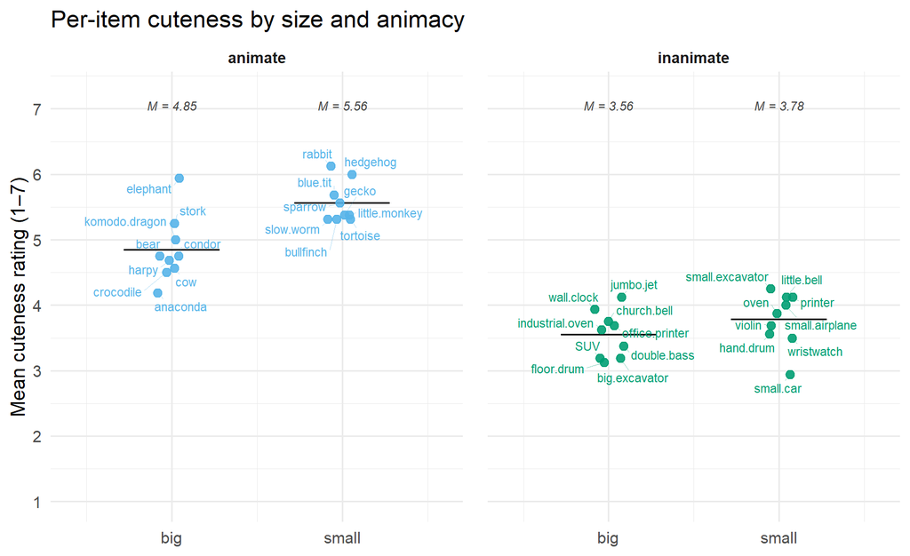

```r
# Build the enriched per-item table (item_cuteness + size/animacy/category).
# Created here so this chunk is self-contained; the later viz chunks
# (cuteness-ranked, cuteness-by-category) reuse the object.
item_cute_full <- item_cuteness |>
  left_join(
    alle |> distinct(item_norm, size, animacy, category) |>
      left_join(item_glossary, by = "item_norm") |>
      select(item_english, size, animacy, category),
    by = "item_english"
  ) |>
  mutate(
    cuteness_se = cuteness_sd / sqrt(n_raters),
    category    = factor(category,
                         levels = c("mammal", "bird", "reptile",
                                    "appliance", "instrument", "vehicle"))
  )

# Pre-jitter so geom_text_repel and geom_point share the same x positions.
set.seed(2137)
plot_dat <- item_cute_full |>
  mutate(
    size_num = as.numeric(factor(size, levels = c("big", "small"))),
    x        = size_num + runif(n(), -0.09, 0.09)
  )

# Cell means as a tiny tibble we draw as crossbars
cell_means <- item_cute_full |>
  group_by(animacy, size) |>
  summarise(cm = mean(cuteness_mean), .groups = "drop") |>
  mutate(size_num = as.numeric(factor(size, levels = c("big", "small"))))

ggplot(plot_dat, aes(x = x, y = cuteness_mean)) +
  geom_segment(data = cell_means,
               aes(x = size_num - 0.28, xend = size_num + 0.28,
                   y = cm, yend = cm),
               colour = "black", linewidth = 0.7,
               inherit.aes = FALSE) +
  geom_text(data = cell_means,
            aes(x = size_num, y = 7.05, label = sprintf("M = %.2f", cm)),
            colour = "grey25", size = 3.1, fontface = "italic",
            inherit.aes = FALSE) +
  geom_point(aes(colour = animacy), size = 2.6, alpha = 0.9) +
  ggrepel::geom_text_repel(
    aes(label = item_english, colour = animacy),
    size = 3.0, max.overlaps = Inf,
    box.padding = 0.32, point.padding = 0.18,
    min.segment.length = 0,
    segment.alpha = 0.45, segment.size = 0.25,
    force = 1.4, force_pull = 0.6,
    seed = 2137,
    show.legend = FALSE
  ) +
  facet_wrap(~ animacy) +
  scale_x_continuous(
    breaks = c(1, 2), labels = c("big", "small"),
    limits = c(0.4, 2.6)
  ) +
  scale_y_continuous(limits = c(1, 7.25), breaks = 1:7) +
  scale_colour_manual(values = colorBlindBlack8[c(3, 4)]) +
  labs(
    x = NULL, y = "Mean cuteness rating (1–7)",
    title    = "Per-item cuteness by size and animacy"
  ) +
  theme(
    legend.position  = "none",
    panel.spacing.x  = unit(1.2, "lines"),
    strip.text       = element_text(face = "bold", size = 11)
  )
```

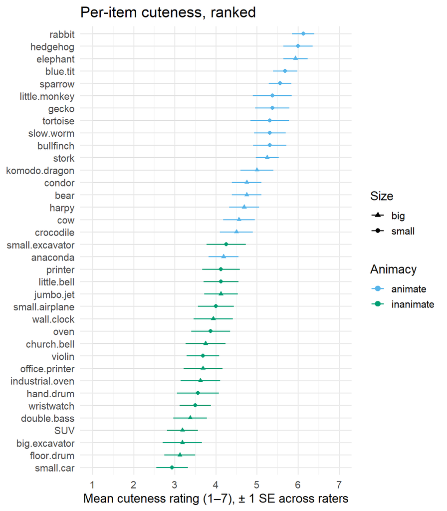

**Figure 2.** Per-item mean cuteness rating across the 36 stimulus items, ranked. Points are item means; horizontal bars are ±1 SE across the 16 raters. Animals (animate) dominate the top of the ranking and objects (inanimate) the bottom – the structural confound between cuteness and animacy is visible at a glance.

```r
ggplot(item_cute_full,
       aes(x = cuteness_mean, y = fct_reorder(item_english, cuteness_mean),
           colour = animacy, shape = size)) +
  geom_segment(aes(xend = 1, yend = fct_reorder(item_english, cuteness_mean)),
               colour = "grey85", linewidth = 0.3) +
  geom_pointrange(aes(xmin = cuteness_mean - cuteness_se,
                      xmax = cuteness_mean + cuteness_se),
                  size = 0.4, fatten = 3) +
  scale_colour_manual(values = colorBlindBlack8[c(3, 4)]) +
  scale_shape_manual(values = c(small = 16, big = 17)) +
  scale_x_continuous(limits = c(1, 7), breaks = 1:7) +
  labs(x = "Mean cuteness rating (1–7), ± 1 SE across raters",
       y = NULL,
       colour = "Animacy", shape = "Size",
       title = "Per-item cuteness, ranked")
```

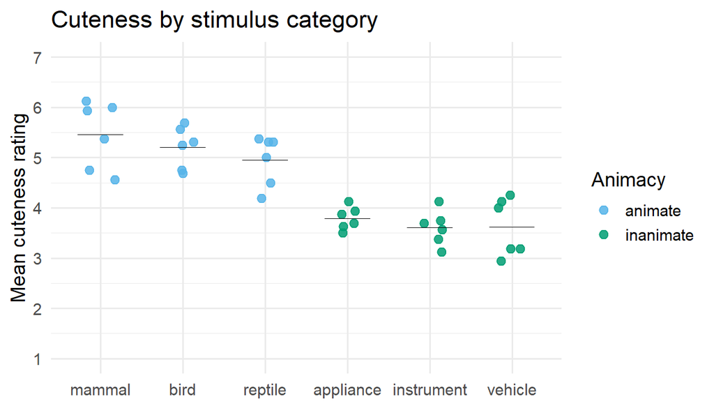

```r
ggplot(item_cute_full, aes(x = category, y = cuteness_mean, colour = animacy)) +
  geom_jitter(width = 0.18, height = 0, size = 2.6, alpha = 0.85) +
  stat_summary(fun = mean, geom = "crossbar",
               width = 0.55, linewidth = 0.3, colour = "black",
               fatten = 0) +
  scale_colour_manual(values = colorBlindBlack8[c(3, 4)]) +
  scale_y_continuous(limits = c(1, 7), breaks = 1:7) +
  labs(x = NULL, y = "Mean cuteness rating",
       colour = "Animacy",
       title = "Cuteness by stimulus category")
```

## 3.5 Cuteness check

```r
# Attach size/animacy to the rater-level ratings and sum-code (+0.5 = big, animate),
# matching the coding used everywhere else in the script.
cuteness_model_dat <- cuteness_long |>
  left_join(item_cute_full |> select(item_english, size, animacy),
            by = "item_english") |>
  filter(!is.na(size), !is.na(animacy)) |>
  mutate(
    size_c    = if_else(size    == "big",     0.5, -0.5),
    animacy_c = if_else(animacy == "animate", 0.5, -0.5)
  )
```

```r
# Multilevel Gaussian model on the 1–7 ratings: effects come out in rating points,
# which match the descriptive "~1.3-point animacy gap" language. By-rater and
# by-item random intercepts handle the clustering the pooled Wilcoxon ignored.
# Priors are weakly informative, scaled to the 1–7 outcome.
m_cuteness <- brm(
  bf(cuteness ~ size_c * animacy_c + (1 | participant) + (1 | item_english)),
  data    = cuteness_model_dat,
  family  = gaussian(),
  prior   = c(prior(normal(0, 2.5),        class = "b"),
              prior(student_t(3, 4, 2.5),  class = "Intercept"),
              prior(student_t(3, 0, 2.5),  class = "sd"),
              prior(student_t(3, 0, 2.5),  class = "sigma")),
  chains  = 4, iter = 8000, warmup = 4000, cores = 4,
  control = list(adapt_delta = 0.95, max_treedepth = 12),
  seed    = 2137,
  file    = paste0(models, "m_cuteness")
)
```

```r
summary(m_cuteness)
```

```
## Ładowanie wymaganej przestrzeni nazw: rstan
```

```
##  Family: gaussian
##   Links: mu = identity
## Formula: cuteness ~ size_c * animacy_c + (1 | participant) + (1 | item_english)
##    Data: cuteness_model_dat (Number of observations: 576)
##   Draws: 4 chains, each with iter = 8000; warmup = 4000; thin = 1;
##          total post-warmup draws = 16000
##
## Multilevel Hyperparameters:
## ~item_english (Number of levels: 36)
##               Estimate Est.Error l-95% CI u-95% CI Rhat Bulk_ESS Tail_ESS
## sd(Intercept)     0.27      0.09     0.09     0.44 1.00     4264     3469
##
## ~participant (Number of levels: 16)
##               Estimate Est.Error l-95% CI u-95% CI Rhat Bulk_ESS Tail_ESS
## sd(Intercept)     1.18      0.24     0.81     1.74 1.00     3006     5797
##
## Regression Coefficients:
##                  Estimate Est.Error l-95% CI u-95% CI Rhat Bulk_ESS Tail_ESS
## Intercept            4.44      0.30     3.84     5.03 1.00     2105     3893
## size_c              -0.47      0.14    -0.74    -0.21 1.00    10971    12127
## animacy_c            1.53      0.14     1.26     1.80 1.00    10353    11463
## size_c:animacy_c    -0.48      0.27    -1.03     0.06 1.00     9895    10084
##
## Further Distributional Parameters:
##       Estimate Est.Error l-95% CI u-95% CI Rhat Bulk_ESS Tail_ESS
## sigma     1.20      0.04     1.13     1.28 1.00    15666    11714
##
## Draws were sampled using sample(hmc). For each parameter, Bulk_ESS
## and Tail_ESS are effective sample size measures, and Rhat is the potential
## scale reduction factor on split chains (at convergence, Rhat = 1).
```

```r
# Same reporting idiom as the rest of the paper: median, 95% HDI, prob. of direction.
describe_posterior(m_cuteness, ci = 0.95, ci_method = "hdi",
                   test = "pd", centrality = "median", effects = "fixed")
```

|  | Parameter | Median | CI | CI_low | CI_high | pd | Rhat | ESS |
| --- | --- | --- | --- | --- | --- | --- | --- | --- |
| 2 | b_Intercept | 4.4340999 | 0.95 | 3.8453763 | 5.03366850 | 1.0000000 | 1.0023459 | 2094.994 |
| 3 | b_size_c | -0.4718709 | 0.95 | -0.7356308 | -0.20384995 | 0.9996250 | 1.0002975 | 11038.060 |
| 1 | b_animacy_c | 1.5273125 | 0.95 | 1.2553035 | 1.79691540 | 1.0000000 | 0.9999896 | 10389.751 |
| 4 | b_size_c:animacy_c | -0.4807348 | 0.95 | -1.0143942 | 0.07221232 | 0.9604375 | 0.9998701 | 9831.147 |

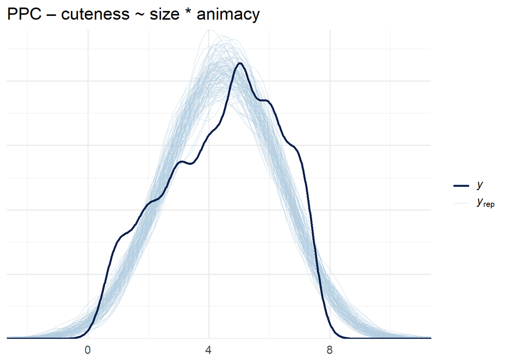

```r
# Optional PPC, consistent with your other models:
pp_check(m_cuteness, ndraws = 100) + ggtitle("PPC – cuteness ~ size * animacy")
```

The images were generated in a uniform “cute” style so that cuteness would not vary with the experimental factors, but a style prompt is no guarantee, so we check directly whether the ratings still line up with size and animacy. We model the raw rater-level ratings – every rater × item, 576 in all – rather than the per-item means, with random intercepts for both rater and item: raters differ in how generously they use the scale, and items differ from one another beyond their size and animacy, and a multilevel model absorbs both kinds of variation instead of letting them inflate the precision of the size and animacy estimates (it is also why a single pooled test would overstate the evidence here). The outcome is treated as continuous, so the coefficients are in rating points on the 1–7 scale; size and animacy are sum-coded (+0.5 = big, animate), so each coefficient is the difference between its two levels.

The check confirms the confound the covariate is meant to handle. Animate referents are rated about 1.5 points cuter than inanimate ones (β = 1.53, 95% CrI [1.26, 1.80]), and small referents about half a point cuter than big ones (β = −0.47, 95% CrI [−0.74, −0.20]); both intervals exclude zero. The size × animacy interaction leans the same way as the descriptive plots – the size effect on cuteness is a little larger for animals than for objects – but its interval crosses zero (β = −0.48, 95% CrI [−1.01, 0.07]), so we read it as a hint rather than a result. All chains converged (R-hat = 1.00). Because cuteness covaries with both factors, it enters the production and perception models as a per-item covariate; whether it actually accounts for the animacy main effect is taken up in §7.8.